## Course: COMPUTATIONAL THINKING FOR GOVERNANCE ANALYTICS

### Prof. José Manuel Magallanes, PhD

- Visiting Professor of Computational Policy at Evans School of Public Policy and Governance, and eScience Institute Senior Data Science Fellow, University of Washington.
- Professor of Government and Political Methodology, Pontificia Universidad Católica del Perú.

# R for Clustering

Collect the data we prepared in Python:

```r
link='https://github.com/EvansDataScience/data/raw/master/hdidemocia.RDS'
# a RDS file from the web needs:
myFile=url(link)

# reading in data:
fromPy=readRDS(file = myFile)

# reset indexes to R format:
row.names(fromPy)=NULL
```

Let’s explore three types of clustering approaches.

1. Partitioning: You will request a particular number of clusters to the algorithm. The algorithm will put every case in one of those clusters. Outliers will affect output.

[figure not shown]

Source: https://en.wikipedia.org/wiki/Cluster_analysis

2. Hierarchizing: You will ask the algorithm to find all possible ways cases can be clustered, individually and in subgroups following a tree-construction/deconstruction approach. You should determine the right amount of clusters.Outliers will affect output.

3. Based on Density

This approach will cluster cases as long as they are close to each other at a predetermined distance. You need to input the distance and the minimal amount of cases in a neighboorhood to be considered a cluster. The algorithm is not affected by outliers.

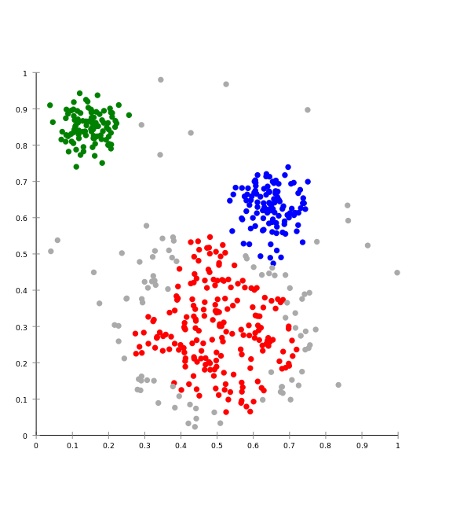

https://commons.wikimedia.org/wiki/Cluster_analysis

## Preparing data:

For all cases, you need the DISTANCE MATRIX:

**a.** Explore variables you will used for clustering

```r
dfClus=fromPy[,c('HDI','Score','kWh_pop')]
summary(dfClus)
```

```
##       HDI             Score          kWh_pop
##  Min.   :0.3766   Min.   :1.320   Min.   :    0.0
##  1st Qu.:0.5810   1st Qu.:3.640   1st Qu.:  405.7
##  Median :0.7472   Median :5.895   Median : 1757.4
##  Mean   :0.7173   Mean   :5.626   Mean   : 3596.1
##  3rd Qu.:0.8473   3rd Qu.:7.202   3rd Qu.: 4640.9
##  Max.   :0.9537   Max.   :9.870   Max.   :50408.6
```

**b.** Rescale units if needed into a new variable:

```r
dfClus=scale(dfClus)

summary(dfClus)
```

```
##       HDI              Score            kWh_pop
##  Min.   :-2.1578   Min.   :-1.9539   Min.   :-0.6375
##  1st Qu.:-0.8633   1st Qu.:-0.9012   1st Qu.:-0.5656
##  Median : 0.1893   Median : 0.1219   Median :-0.3259
##  Mean   : 0.0000   Mean   : 0.0000   Mean   : 0.0000
##  3rd Qu.: 0.8235   3rd Qu.: 0.7152   3rd Qu.: 0.1852
##  Max.   : 1.4972   Max.   : 1.9255   Max.   : 8.2983
```

**c.** Rename subset indexes and Verify what your input is:

```r
row.names(dfClus)=fromPy$Country
head(dfClus)
```

```
##                  HDI    Score   kWh_pop
## Norway      1.497159 1.925539 3.3245444
## Switzerland 1.448061 1.544401 0.5956376
## Ireland     1.426127 1.639686 0.2419177
## Germany     1.402769 1.385594 0.5489588
## Australia   1.400197 1.571625 0.9593392
## Iceland     1.400800 1.793956 8.2983293
```

**d.** Set random seed:

```r
set.seed(999) # this is for replicability of results
```

**e.** Decide distance method and compute distance matrix:

```r
library(cluster)
dfClus_D=cluster::daisy(x=dfClus)
```

## Partitioning technique

### 1. Apply function: you need to indicate the amount of clusters required.

```r
NumCluster=4
res.pam = pam(x=dfClus_D,
              k = NumCluster,
              cluster.only = F)
```

### 2. Clustering results.

**2.1** Add results to original data frame:

```r
fromPy$pam=as.factor(res.pam$clustering)
```

**2.2** Query data frame as needed:

Example 1:

```r
fromPy[fromPy$pam==1,'Country']
```

```
##  [1] "Norway"              "Switzerland"         "Ireland"
##  [4] "Germany"             "Australia"           "Iceland"
##  [7] "Sweden"              "Singapore"           "Netherlands"
## [10] "Denmark"             "Finland"             "Canada"
## [13] "New Zealand"         "United Kingdom"      "United States"
## [16] "Belgium"             "Japan"               "Austria"
## [19] "Luxembourg"          "Israel"              "Slovenia"
## [22] "Spain"               "France"              "Malta"
## [25] "Italy"               "Estonia"             "Cyprus"
## [28] "Greece"              "Poland"              "Lithuania"
## [31] "Slovakia"            "Latvia"              "Portugal"
## [34] "Chile"               "Kuwait"              "Uruguay"
## [37] "Trinidad and Tobago"
```

Example 2:

```r
fromPy[fromPy$Country=="Peru",'pam']
```

```
## [1] 3
## Levels: 1 2 3 4
```

**2.2** REPORT: Table of clusters

```r
table(fromPy$pam)
```

```
##
##  1  2  3  4
## 37 22 46 39
```

### 3. Evaluate Results.

**3.1** REPORT: Average silhouettes

```r
library(factoextra)
```

```
##   cluster size ave.sil.width
## 1       1   37          0.24
## 2       2   22          0.31
## 3       3   46          0.50
## 4       4   39          0.49
```

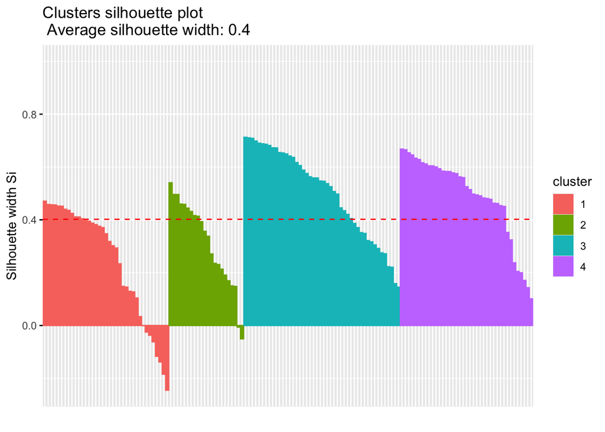

```r
fviz_silhouette(res.pam)
```

**3.2** REPORT: Detecting anomalies

1. Save individual silhouettes:

```r
pamEval=data.frame(res.pam$silinfo$widths)
head(pamEval)
```

```
##             cluster neighbor sil_width
## Australia         1        3 0.4708210
## Switzerland       1        3 0.4582347
## Germany           1        3 0.4570021
## New Zealand       1        3 0.4563924
## Luxembourg        1        3 0.4522214
## Austria           1        3 0.4516604
```

2. Request negative silhouettes: The ones that are poorly clustered.

```r
pamEval[pamEval$sil_width<0,]
```

```
##                     cluster neighbor     sil_width
## Trinidad and Tobago       1        3 -0.0005199807
## Lithuania                 1        3 -0.0249031297
## Cyprus                    1        3 -0.0369564568
## Slovakia                  1        3 -0.0616326106
## Kuwait                    1        2 -0.1165750129
## Latvia                    1        3 -0.1379449436
## Uruguay                   1        3 -0.1842637550
## Poland                    1        3 -0.2448842351
## Lebanon                   2        3 -0.0061096842
## Nicaragua                 2        4 -0.0505232366
```

## Hierarchizing: agglomerative

### 1. Apply function:

```r
library(factoextra)

res.agnes= hcut(dfClus_D,
                k = NumCluster,isdiss=T,
                hc_func='agnes',
                hc_method = "ward.D2")
```

### 2. Clustering results.

**2.1** Add results to original data frame:

```r
fromPy$agn=as.factor(res.agnes$cluster)
```

**2.2** Query data frame as needed:

Example 1:

```r
fromPy[fromPy$agn==1,'Country']
```

```
##  [1] "Norway"                 "Switzerland"            "Ireland"
##  [4] "Germany"                "Australia"              "Sweden"
##  [7] "Singapore"              "Netherlands"            "Denmark"
## [10] "Finland"                "Canada"                 "New Zealand"
## [13] "United Kingdom"         "United States"          "Belgium"
## [16] "Japan"                  "Austria"                "Luxembourg"
## [19] "Israel"                 "Slovenia"               "Spain"
## [22] "France"                 "Malta"                  "Italy"
## [25] "Estonia"                "Cyprus"                 "Greece"
## [28] "Poland"                 "Lithuania"              "Slovakia"
## [31] "Latvia"                 "Portugal"               "Chile"
## [34] "Hungary"                "Croatia"                "Argentina"
## [37] "Bulgaria"               "Montenegro"             "Romania"
## [40] "Uruguay"                "Malaysia"               "Serbia"
## [43] "Trinidad and Tobago"    "Mauritius"              "Panama"
## [46] "Costa Rica"             "Albania"                "Georgia"
## [49] "Sri Lanka"              "Bosnia and Herzegovina" "Mexico"
## [52] "Thailand"               "Brazil"                 "Colombia"
## [55] "Armenia"                "Peru"                   "Ecuador"
## [58] "Ukraine"                "Dominican Republic"     "Tunisia"
## [61] "Mongolia"               "Botswana"               "Jamaica"
## [64] "Fiji"                   "Paraguay"               "Suriname"
## [67] "Philippines"            "Indonesia"              "South Africa"
```

Example 2:

```r
fromPy[fromPy$Country=="Peru",'agn']
```

```
## [1] 1
## Levels: 1 2 3 4
```

**2.2** REPORT: Table of clusters

Reporting results:

```r
table(fromPy$agn)
```

```
##
##  1  2  3  4
## 69  1 23 51
```

### 3. Evaluate Results.

**3.1a** REPORT: Dendogram

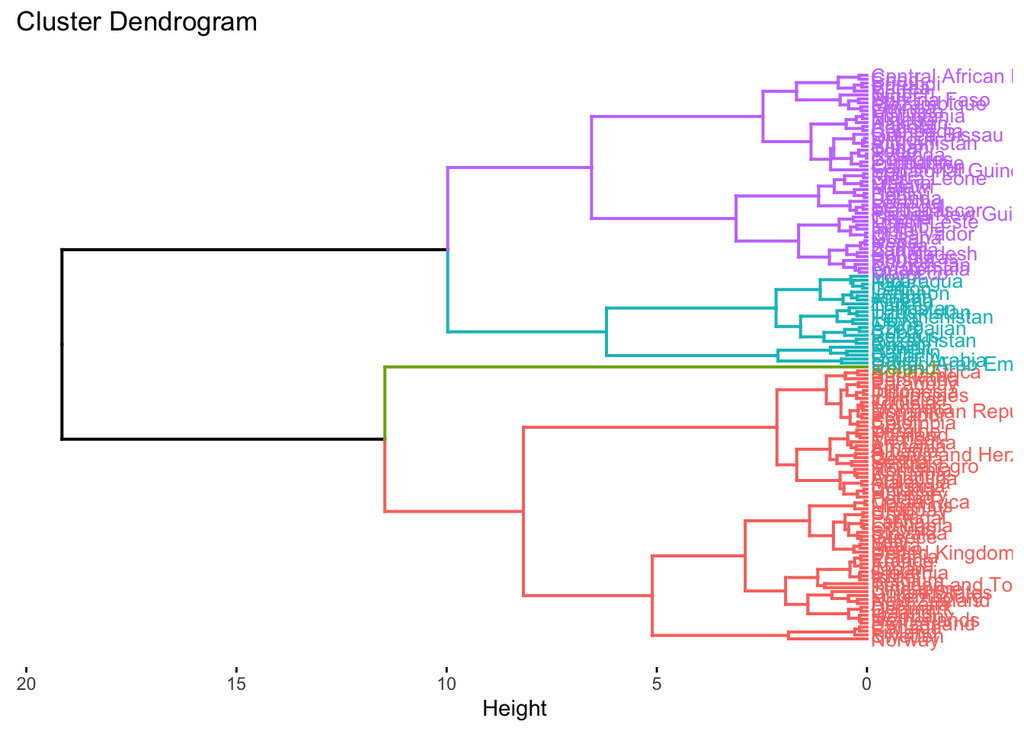

```r
fviz_dend(res.agnes,k=NumCluster, cex = 0.7, horiz = T)
```

**3.1b** REPORT: Average silhouettes:

```
##   cluster size ave.sil.width
## 1       1   69          0.48
## 2       2    1          0.00
## 3       3   23          0.31
## 4       4   51          0.45
```

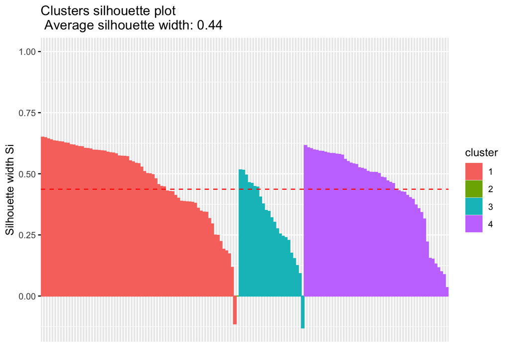

```r
library(factoextra)
fviz_silhouette(res.agnes)
```

**3.2** REPORT: Detecting anomalies

1. Saving silhouettes:

```r
agnEval=data.frame(res.agnes$silinfo$widths)
head(agnEval)
```

```
##           cluster neighbor sil_width
## Portugal        1        3 0.6498083
## Chile           1        3 0.6475464
## Malta           1        3 0.6429652
## Spain           1        3 0.6389964
## Latvia          1        3 0.6347736
## Lithuania       1        3 0.6333718
```

2. Requesting negative silhouettes:

```r
agnEval[agnEval$sil_width<0,]
```

```
##                        cluster neighbor  sil_width
## Bosnia and Herzegovina       1        3 -0.1135578
## Nicaragua                    3        4 -0.1301846
```

## Hierarchizing: divisive

### 1. Apply function: you need to indicate the amount of clusters required.

```r
library(factoextra)

res.diana= hcut(dfClus_D, k = NumCluster,
                 hc_func='diana',
                 hc_method = "ward.D")
```

### 2. Clustering results.

**2.1** Add results to original data frame:

```r
fromPy$dia=as.factor(res.diana$cluster)
```

**2.2** Query data frame as needed:

Example 1:

```r
fromPy[fromPy$dia==1,'Country']
```

```
##  [1] "Norway"         "Switzerland"    "Ireland"        "Germany"
##  [5] "Australia"      "Sweden"         "Singapore"      "Netherlands"
##  [9] "Denmark"        "Finland"        "Canada"         "New Zealand"
## [13] "United Kingdom" "United States"  "Belgium"        "Japan"
## [17] "Austria"        "Luxembourg"     "Israel"         "Slovenia"
## [21] "Spain"          "France"         "Malta"          "Estonia"
## [25] "Qatar"          "Bahrain"        "Kuwait"
```

Example 2:

```r
fromPy[fromPy$Country=="Peru",'dia']
```

```
## [1] 3
## Levels: 1 2 3 4
```

**2.2** REPORT: Table of clusters

Reporting results:

```r
table(fromPy$dia)
```

```
##
##  1  2  3  4
## 27  1 46 70
```

### 3. Evaluate Results.

**3.1a** REPORT: Dendogram

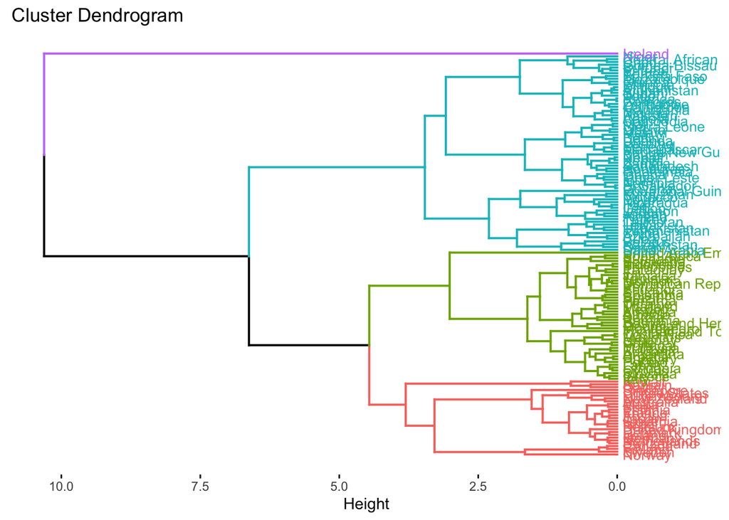

```r
fviz_dend(res.diana,k=NumCluster, cex = 0.7, horiz = T)
```

**3.1b** REPORT: Average silhouettes:

```
##   cluster size ave.sil.width
## 1       1   27          0.23
## 2       2    1          0.00
## 3       3   46          0.51
## 4       4   70          0.30
```

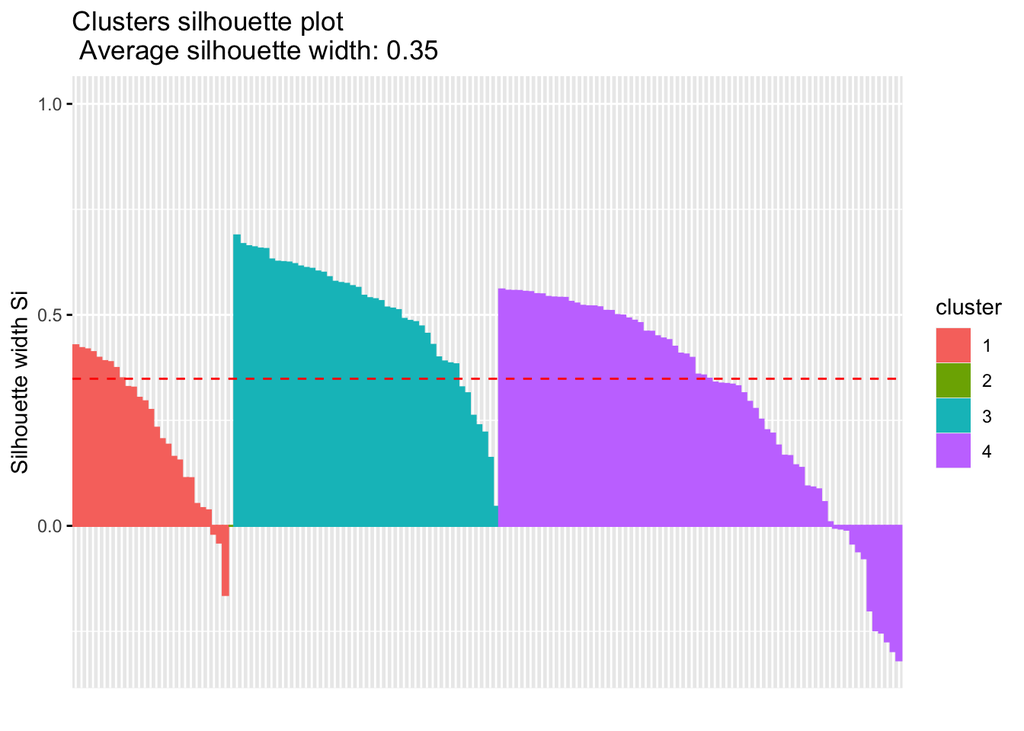

```r
library(factoextra)
fviz_silhouette(res.diana)
```

**3.2** REPORT: Detecting anomalies

1. Saving silhouettes:

```r
diaEval=data.frame(res.diana$silinfo$widths)
head(diaEval)
```

```
##             cluster neighbor sil_width
## Australia         1        3 0.4277852
## Sweden            1        3 0.4210771
## Luxembourg        1        3 0.4180418
## Canada            1        3 0.4115206
## Finland           1        3 0.3981896
## New Zealand       1        3 0.3902107
```

2. Requesting negative silhouettes:

```r
diaEval[diaEval$sil_width<0,]
```

```
##              cluster neighbor    sil_width
## Spain              1        3 -0.018629148
## Singapore          1        3 -0.039453415
## Malta              1        3 -0.163622107
## Kazakhstan         4        3 -0.004459444
## Saudi Arabia       4        3 -0.006299668
## Algeria            4        3 -0.008956244
## Ghana              4        3 -0.041888602
## Lebanon            4        3 -0.060248175
## Oman               4        3 -0.076665817
## Turkey             4        3 -0.200229913
## Timor-Leste        4        3 -0.247318651
## Namibia            4        3 -0.252826005
## El Salvador        4        3 -0.273672078
## Guyana             4        3 -0.296752474
## India              4        3 -0.318476601
```

## Density-based clustering

You input the distance and the minimal number of neighbors that form a cluster.

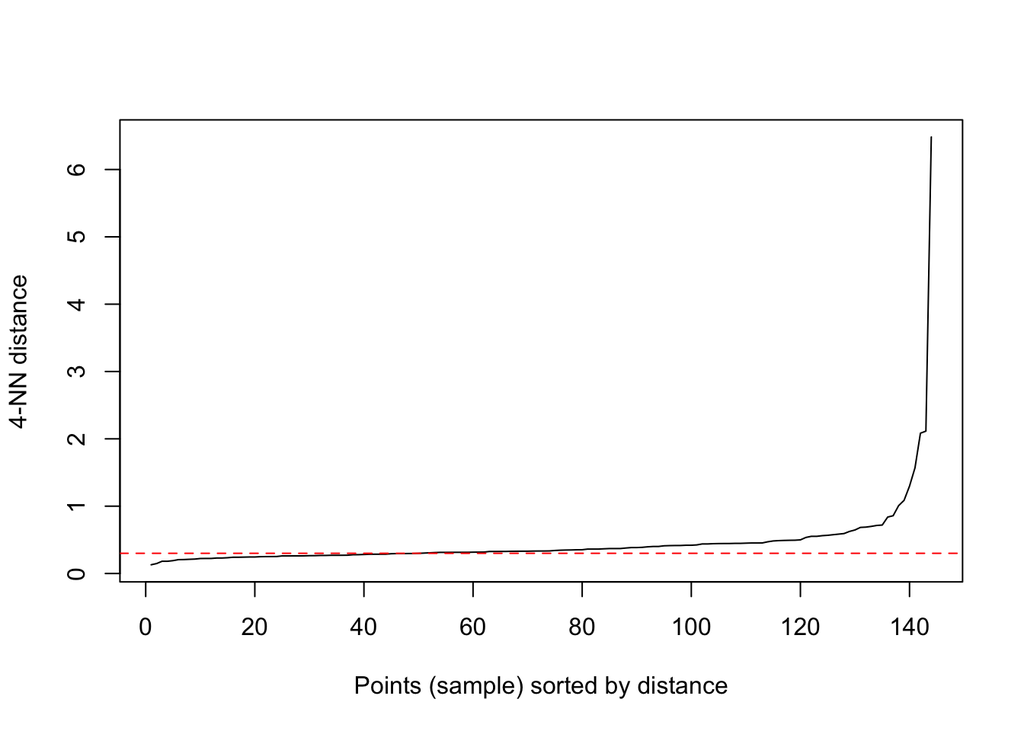

```r
library(dbscan)
#minNeighs>= num cols in data
minNeighs=4
kNNdistplot(dfClus_D, k = minNeighs)
abline(h=0.3, col = "red", lty=2)
```

```r
distance=0.3
res.db = dbscan::dbscan(dfClus_D,
                        eps=distance,
                        minPts=minNeighs)
```

**REPORT**:

How many cluster were produced? and How many outliers are there?

```r
# '0' identifies outliers:
res.db
```

```
## DBSCAN clustering for 144 objects.
## Parameters: eps = 0.3, minPts = 4
## The clustering contains 4 cluster(s) and 43 noise points.
##
##  0  1  2  3  4
## 43 58  6  6 31
##
## Available fields: cluster, eps, minPts
```

Save result:

```r
fromPy$db=as.factor(res.db$cluster)
```

# How to compare clustering?

- Prepare a bidimensional map:

```r
projectedData = cmdscale(dfClus_D, k=2)
#
# save coordinates to original data frame:
fromPy$dim1 = projectedData[,1]
fromPy$dim2 = projectedData[,2]
```

- See the “map”:

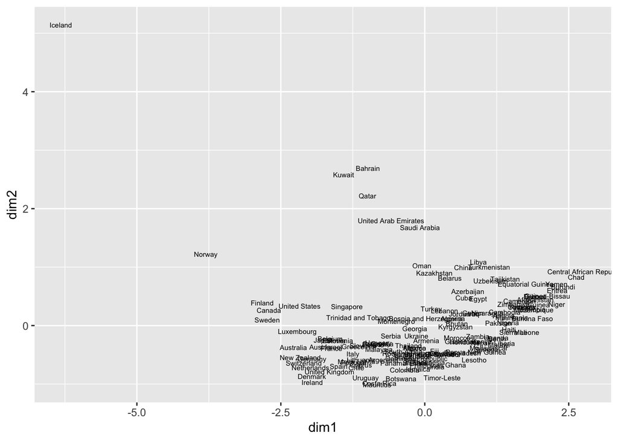

```r
base= ggplot(data=fromPy,
             aes(x=dim1, y=dim2,
                 label=Country))
base + geom_text(size=2)
```

- Plot results from PAM:

```r
pamPlot=base + labs(title = "PAM") + geom_point(size=2,
                                              aes(color=pam),
                                              show.legend = F)
```

- Plot results from Hierarchical AGNES:

```r
agnPlot=base + labs(title = "AGNES") + geom_point(size=2,
                                              aes(color=agn),
                                              show.legend = F)
```

- Plot results from Hierarchical DIANA:

```r
diaPlot=base + labs(title = "DIANA") + geom_point(size=2,
                                              aes(color=dia),
                                              show.legend = F)
```

Compare visually:

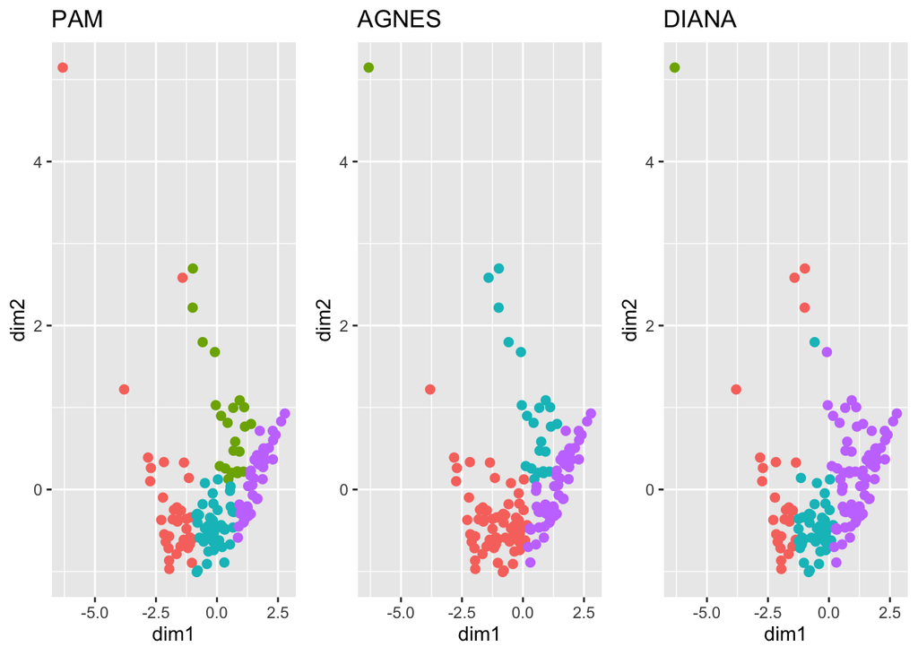

```r
library(ggpubr)
ggarrange(pamPlot, agnPlot, diaPlot,ncol = 3)
```

- Plot results from DBSCAN:

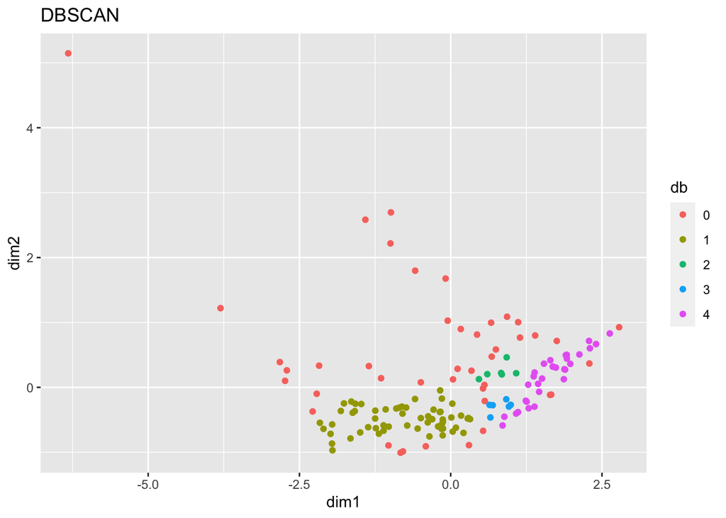

```r
dbPlot= base + labs(title = "DBSCAN") + geom_point(aes(color=db),
                                               show.legend = T)
dbPlot
```

Annotating:

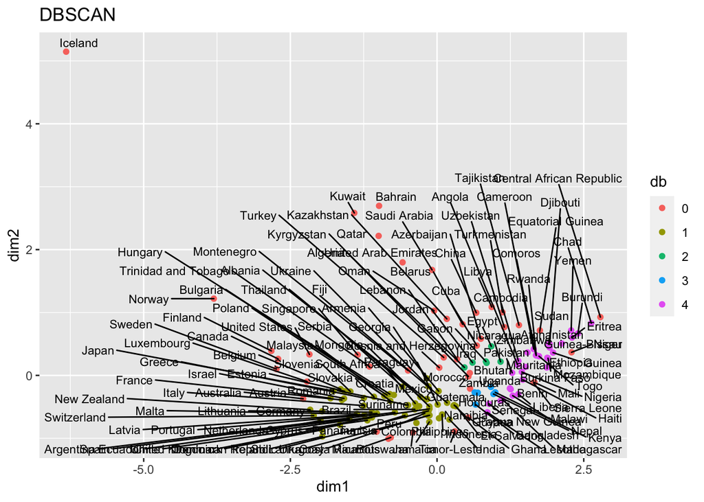

```r
library(ggrepel)
dbPlot + geom_text_repel(size=3,aes(label=Country))
```

Annotating outliers:

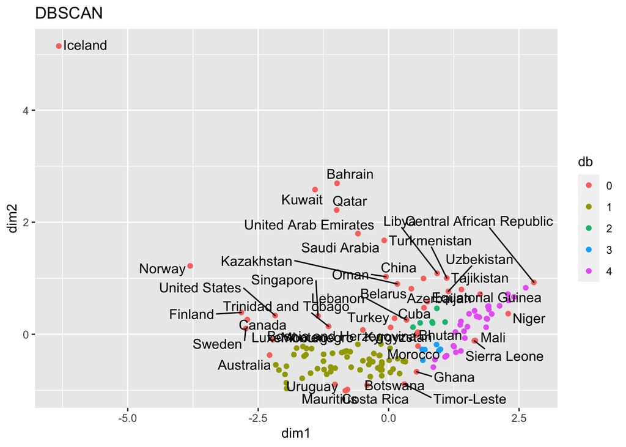

```r
LABEL=ifelse(fromPy$db==0,fromPy$Country,"")

dbPlot + geom_text_repel(aes(label=LABEL))
```

# FACTOR ANALYSIS

You would like turn the 5 dimensions of democracy index into one, without following an arithmetic approach, but an algebraic one, instead. Dimension reduction is the job of latent variable analysis, and that’s the way proposed here.

Let me subset our original data frame:

```r
subDemo=fromPy[,c(8:12)]
```

Our *subDemo* DF has the data to compute the one index we need. I will show the technique called **confirmatory factor analysis**:

```r
names(subDemo)
```

```
## [1] "Electoralprocessandpluralism" "Functioningofgovernment"
## [3] "Politicalparticipation"       "Politicalculture"
## [5] "Civilliberties"
```

```r
library(lavaan)
model='
dem=~Electoralprocessandpluralism + Functioningofgovernment + Politicalparticipation + Politicalculture + Civilliberties
'

fit<-cfa(model, data = subDemo,std.lv=TRUE)
indexCFA=lavPredict(fit)
```

The index computed is not in a range from 0 to 10:

```r
library(magrittr)
indexCFA%>%head(10)
```

```
##             dem
##  [1,] 1.6030873
##  [2,] 1.3239287
##  [3,] 1.5234433
##  [4,] 1.3341783
##  [5,] 1.5221480
##  [6,] 1.5438916
##  [7,] 1.4445449
##  [8,] 0.2712839
##  [9,] 1.3299498
## [10,] 1.3688516
```

We force its return to “0 to 10”:

```r
library(scales)
indexCFANorm=rescale(as.vector(indexCFA),
                     to = c(0, 10))
```

So, this is our index:

```r
fromPy$demo_FA=indexCFANorm
```

Let me plot this index:

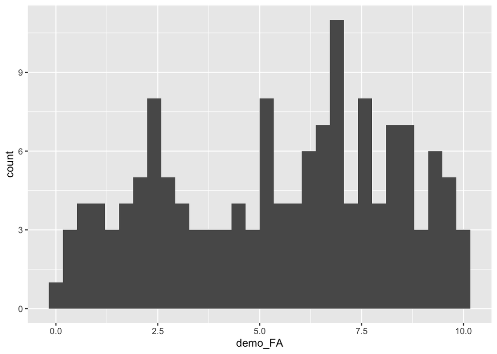

```r
library(ggplot2)
base=ggplot(data=fromPy,
            aes(x=demo_FA))
base+geom_histogram()
```

Let me compare the new index with the original score:

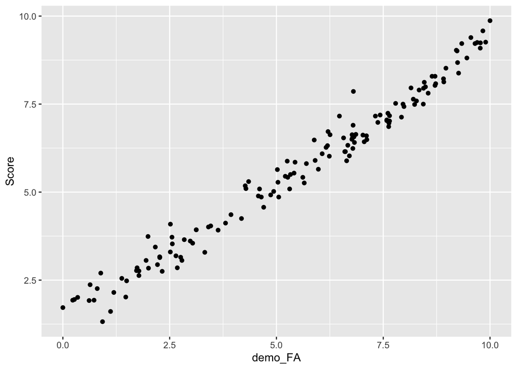

```r
base=ggplot(data=fromPy,
            aes(x=demo_FA,y=Score))
base+geom_point()
```

Let me see some evaluation measures of our index for democracy:

```r
evalCFA1=parameterEstimates(fit, standardized =TRUE)
```

- Loadings

```r
evalCFA1[evalCFA1$op=="=~",c('rhs','std.all','pvalue')]
```

```
##                            rhs std.all pvalue
## 1 Electoralprocessandpluralism   0.924      0
## 2      Functioningofgovernment   0.876      0
## 3       Politicalparticipation   0.803      0
## 4             Politicalculture   0.681      0
## 5               Civilliberties   0.974      0
```

- Some coefficients:

```r
evalCFA2=as.list(fitMeasures(fit))
```

- You want p.value of Chi-Square greater than 0.05:

```r
evalCFA2[c("chisq", "df", "pvalue")]
```

```
## $chisq
## [1] 41.37599
##
## $df
## [1] 5
##
## $pvalue
## [1] 7.876857e-08
```

- You want the Tucker-Lewis > 0.9:

```r
evalCFA2$tli # > 0.90
```

```
## [1] 0.8945603
```

- You want RMSEA < 0.05:

```r
evalCFA2[c( 'rmsea.ci.lower','rmsea','rmsea.ci.upper')]
```

```
## $rmsea.ci.lower
## [1] 0.1644497
##
## $rmsea
## [1] 0.2247714
##
## $rmsea.ci.upper
## [1] 0.2904736
```

You can see how it looks:

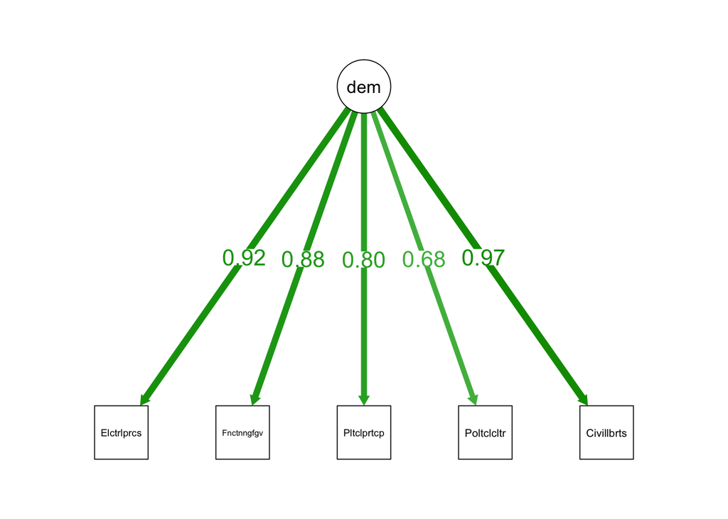

```r
library(semPlot)
semPaths(fit, what='std', nCharNodes=10, sizeMan=8,
         edge.label.cex=1.5, fade=T,residuals = F)
```